# TimeSeries

Maksym Rud’

15 11 2020

## Time Series Plotting

As we have some NA values in our observations. We should make an imputation to be sure that we can rely on further data processing and analysis steps. I will use interpolation method.

```r
france_dataTS.withoutNA <- na_interpolation(france_dataTS)
```

Let’s investigate our model to check if it has any paticular pattern.

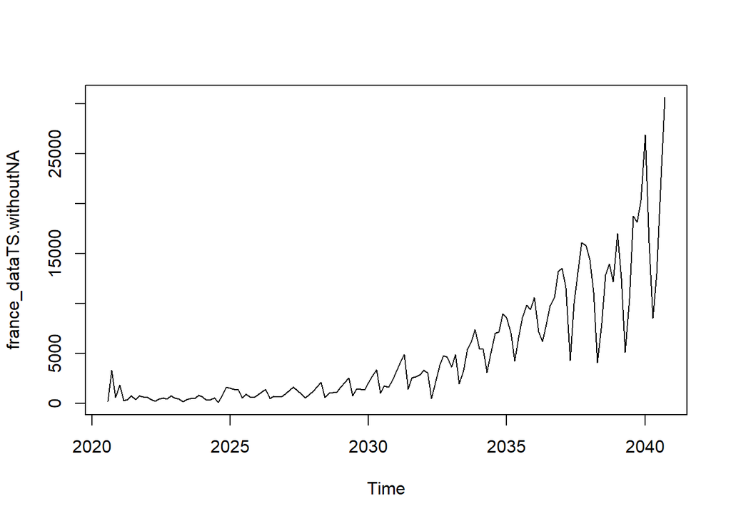

```r
plot.ts(france_dataTS.withoutNA)
```

Curve of observations seems like an exponential tendency of growth and has an 7 days seasoning

Thus, we can try to estimate the trend component of this time series by smoothing using a simple moving average and seasonal decomposing. To smooth the time series using a simple moving average and plot the smoothed time series data, we type:

## Smoothing time series data

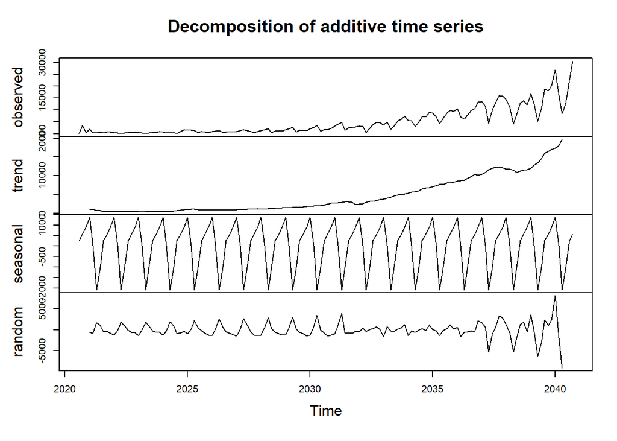

```r
france_decomp <- decompose(france_dataTS.withoutNA)
plot(france_decomp)
```

We can see that our variance is increasing over time. So it will be more convinient to log our function

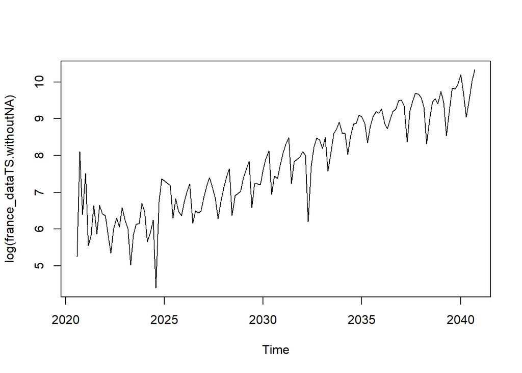

```r
plot.ts(log(france_dataTS.withoutNA))
```

```r
france_dataTS.withoutNA.LOG <- log10(france_dataTS.withoutNA)
```

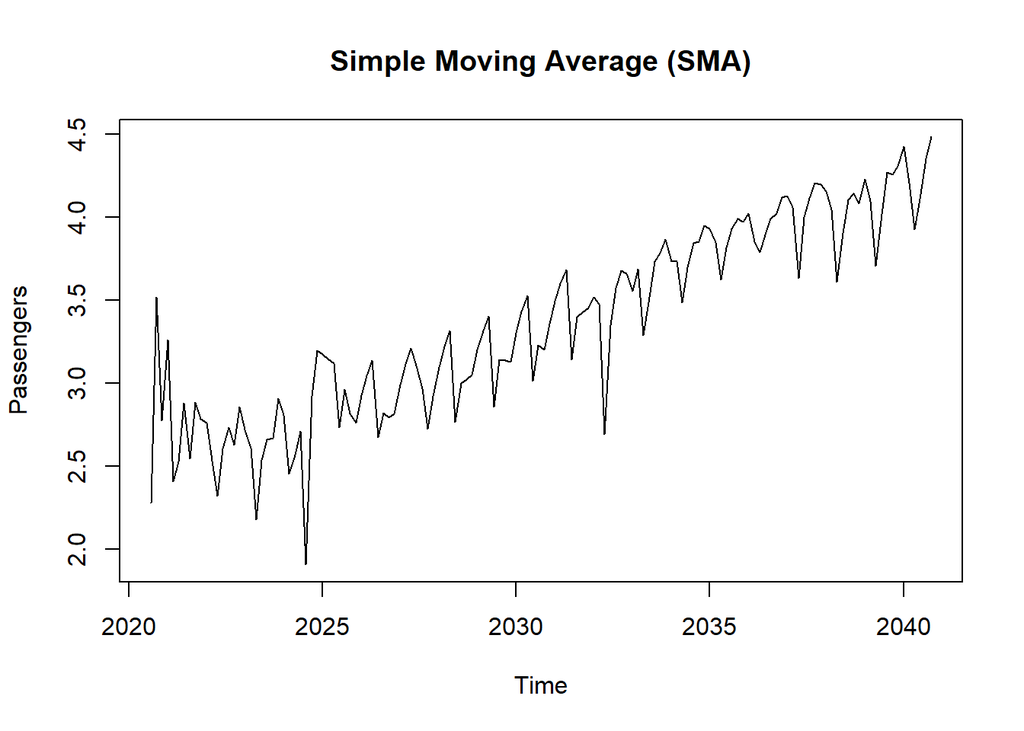

```r
plot(france_dataTS.withoutNA.LOG,main='Simple Moving Average (SMA)',ylab='Passengers')
```

Checking Seasonality

```r
summary(wo(france_dataTS.withoutNA.LOG))
```

```
## Test used:  WO
##
## Test statistic:  1
## P-value:  0.0001118985 1.111129e-08 0.001257614
##
## The WO - test identifies seasonality
```

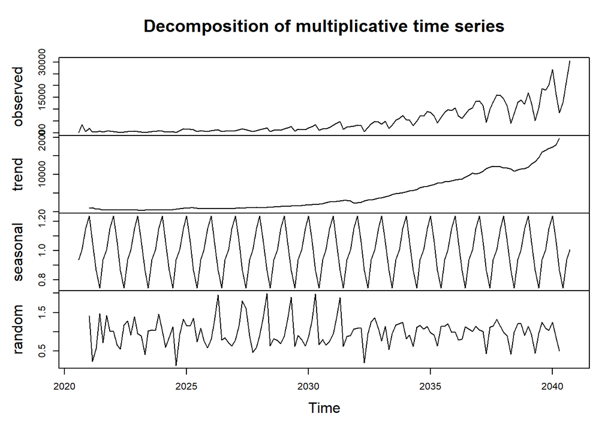

```r
france_decomp <- decompose(france_dataTS.withoutNA, type = "multiplicative")
plot(france_decomp)
```

## Test if Time Series is Stationary

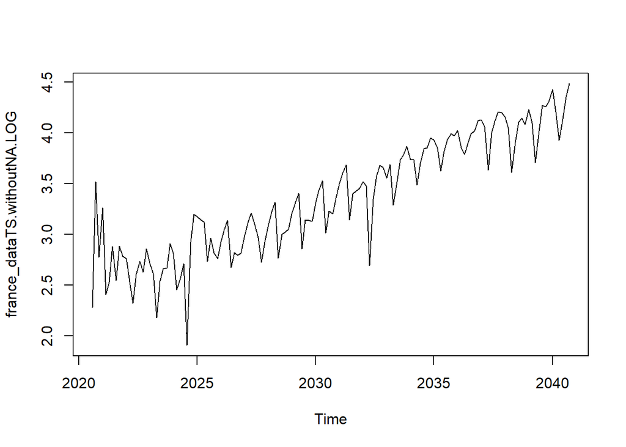

```r
plot(france_dataTS.withoutNA.LOG)
```

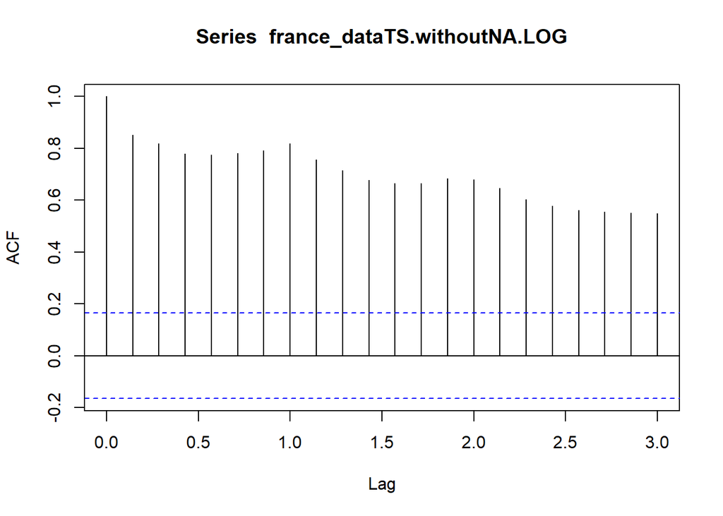

```r
acfdata <- acf(france_dataTS.withoutNA.LOG)
```

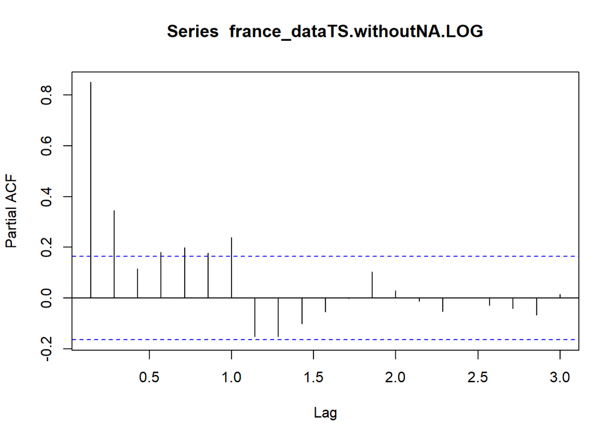

```r
acfdata <- pacf(france_dataTS.withoutNA.LOG)
```

```r
france_dataTS.withoutNA.LOG.differenced <- diff(france_dataTS.withoutNA.LOG, lag = 7)
summary(wo(france_dataTS.withoutNA.LOG.differenced))
```

```
## Test used:  WO
##
## Test statistic:  0
## P-value:  1 1 0.9817565
##
## The WO - test does not identify  seasonality
```

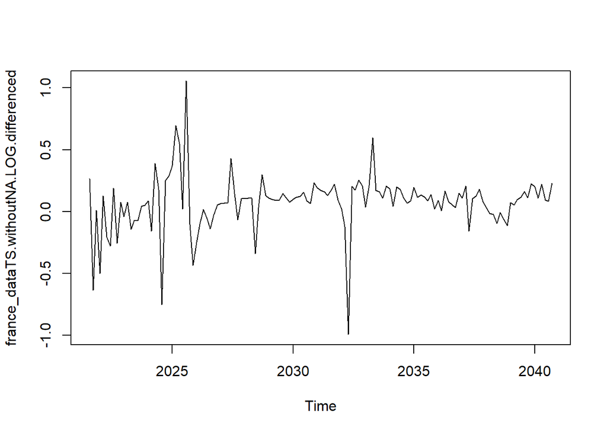

```r
plot(france_dataTS.withoutNA.LOG.differenced, type = "l")
```

Autoregressive component: A purely AR model forecasts only using a combination of the past values sorta like linear regression where the number of AR terms used is directly proportional to the number of previous periods taken into consideration for the forecasting. Use AR terms in the model when the. ACF plots show autocorrelation decaying towards zero PACF plot cuts off quickly towards zero ACF of a stationary series shows positive at lag-1

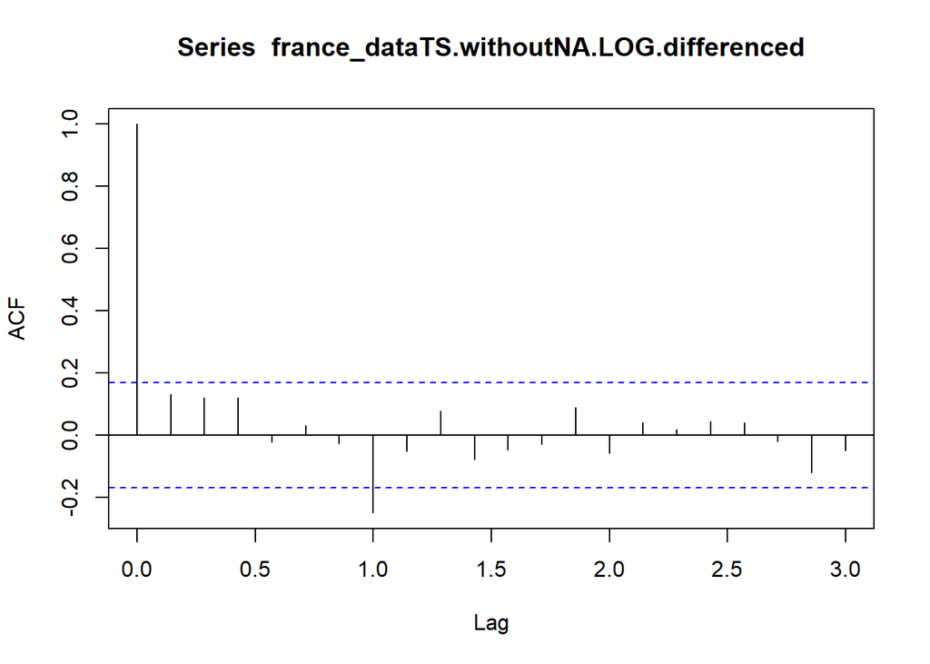

```r
acfdata <- acf(france_dataTS.withoutNA.LOG.differenced)
```

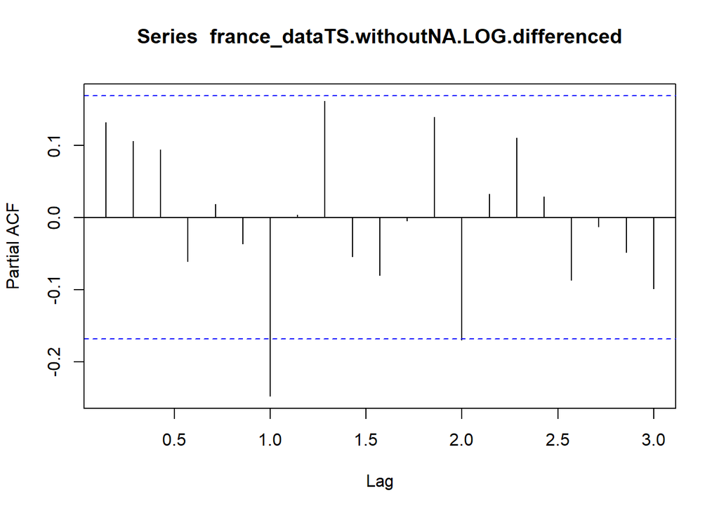

```r
acfdata <- pacf(france_dataTS.withoutNA.LOG.differenced)
```

```r
adf.test(france_dataTS.withoutNA.LOG.differenced)
```

```
##
##  Augmented Dickey-Fuller Test
##
## data:  france_dataTS.withoutNA.LOG.differenced
## Dickey-Fuller = -4.6552, Lag order = 5, p-value = 0.01
## alternative hypothesis: stationary
```

```r
fit0 <- auto.arima(france_dataTS.withoutNA.LOG, d = 1, approximation = FALSE, seasonal = TRUE)
```

```r
AIC(arima(france_dataTS.withoutNA.LOG, order = c(0, 1, 1), seasonal = list(order = c(1, 0, 0), period = 7)))
```

```
## [1] -34.44613
```

```r
AIC(arima(france_dataTS.withoutNA.LOG, order = c(0, 1, 1), seasonal = list(order = c(1, 0, 1), period = 7)))
```

```
## [1] -35.86164
```

```r
AIC(arima(france_dataTS.withoutNA.LOG, order = c(1, 1, 0), seasonal = list(order = c(1, 0, 1), period = 7)))
```

```
## [1] -7.203817
```

```r
AIC(arima(france_dataTS.withoutNA.LOG, order = c(1, 1, 0), seasonal = list(order = c(1, 0, 0), period = 7)))
```

```
## [1] -5.872153
```

```r
fit <-  arima(france_dataTS.withoutNA.LOG, order = c(1, 1, 0), seasonal = list(order = c(1, 0, 0), period = 7))
fit1 <- arima(france_dataTS.withoutNA.LOG, order = c(0, 1, 1), seasonal = list(order = c(1, 0, 1), period = 7))
```

```r
summary(fit0)
```

```
## Series: france_dataTS.withoutNA.LOG
## ARIMA(0,1,1)(1,0,0)[7] with drift
##
## Coefficients:
##           ma1    sar1   drift
##       -0.9158  0.5269  0.0107
## s.e.   0.0534  0.0819  0.0032
##
## sigma^2 estimated as 0.04249:  log likelihood=22.4
## AIC=-36.8   AICc=-36.51   BIC=-25.01
##
## Training set error measures:
##                       ME      RMSE       MAE        MPE     MAPE      MASE
## Training set 0.002382607 0.2032115 0.1352973 -0.4455424 4.475321 0.8077715
##                   ACF1
## Training set 0.1326185
```

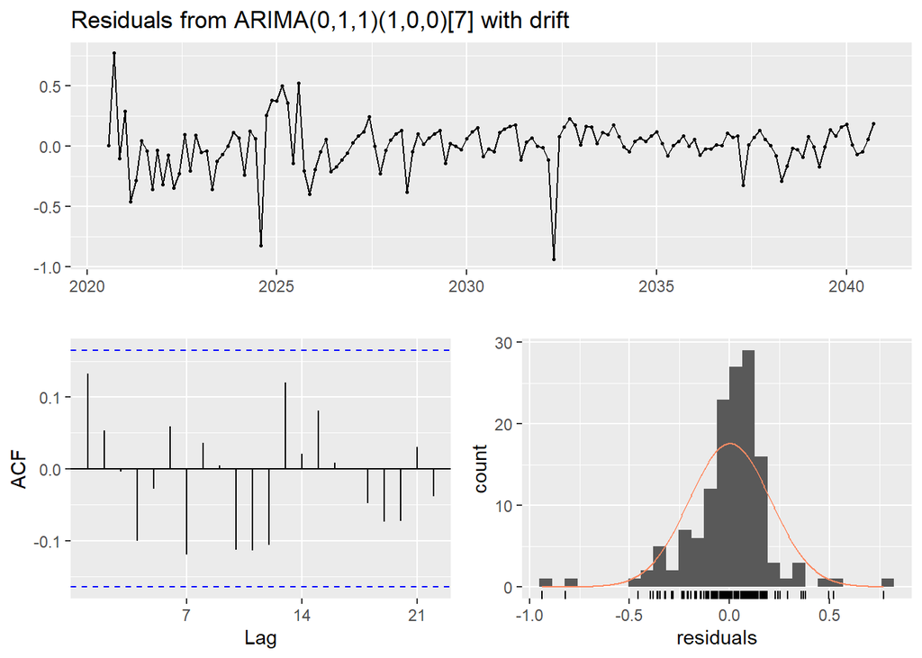

```
##
##  Ljung-Box test
##
## data:  Residuals from ARIMA(0,1,1)(1,0,0)[7] with drift
## Q* = 15.568, df = 11, p-value = 0.1579
##
## Model df: 3.   Total lags used: 14
```

```r
checkresiduals(fit0)
```

```r
summary(fit)
```

```
##
## Call:
## arima(x = france_dataTS.withoutNA.LOG, order = c(1, 1, 0), seasonal = list(order = c(1,
##     0, 0), period = 7))
##
## Coefficients:
##           ar1    sar1
##       -0.5079  0.5283
## s.e.   0.0789  0.0787
##
## sigma^2 estimated as 0.05285:  log likelihood = 5.94,  aic = -5.87
##
## Training set error measures:
##                      ME      RMSE       MAE         MPE     MAPE      MASE
## Training set 0.01246242 0.2290718 0.1519495 -0.02411514 5.016833 0.7664776
##                     ACF1
## Training set -0.06168477
```

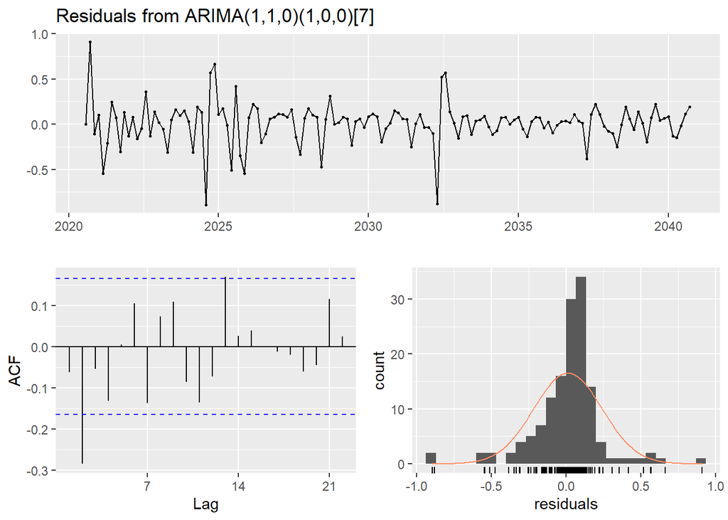

```
##
##  Ljung-Box test
##
## data:  Residuals from ARIMA(1,1,0)(1,0,0)[7]
## Q* = 31.917, df = 12, p-value = 0.001425
##
## Model df: 2.   Total lags used: 14
```

```r
checkresiduals(fit)
```

```r
summary(fit1)
```

```
##
## Call:
## arima(x = france_dataTS.withoutNA.LOG, order = c(0, 1, 1), seasonal = list(order = c(1,
##     0, 1), period = 7))
##
## Coefficients:
##           ma1    sar1     sma1
##       -0.8532  0.7861  -0.3324
## s.e.   0.0492  0.1010   0.1536
##
## sigma^2 estimated as 0.04162:  log likelihood = 21.93,  aic = -35.86
##
## Training set error measures:
##                      ME      RMSE       MAE       MPE     MAPE      MASE
## Training set 0.03071838 0.2032989 0.1373813 0.5318712 4.519026 0.6929911
##                    ACF1
## Training set 0.05124436
```

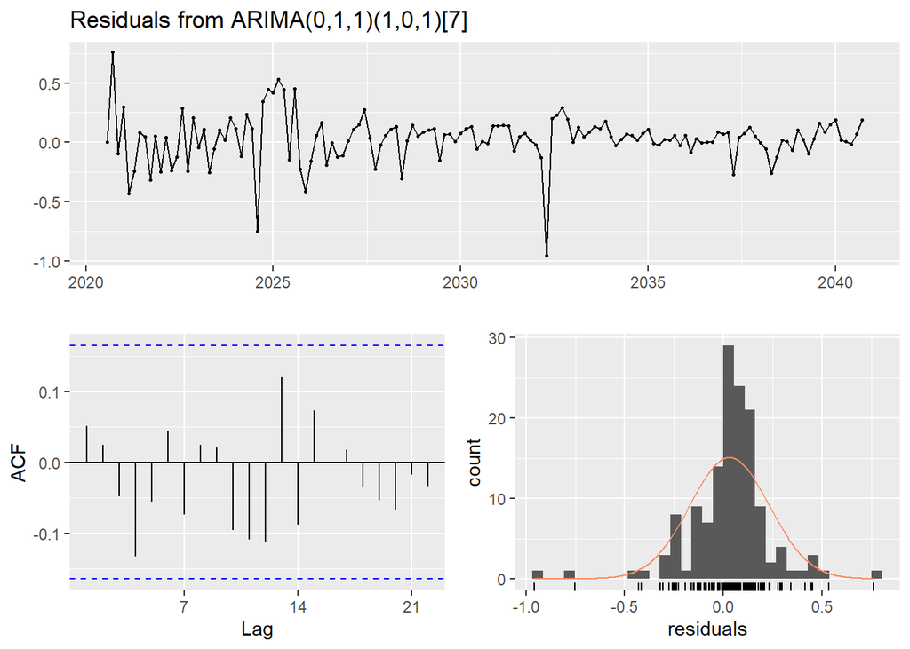

```
##
##  Ljung-Box test
##
## data:  Residuals from ARIMA(0,1,1)(1,0,1)[7]
## Q* = 13.897, df = 11, p-value = 0.2387
##
## Model df: 3.   Total lags used: 14
```

```r
checkresiduals(fit1)
```

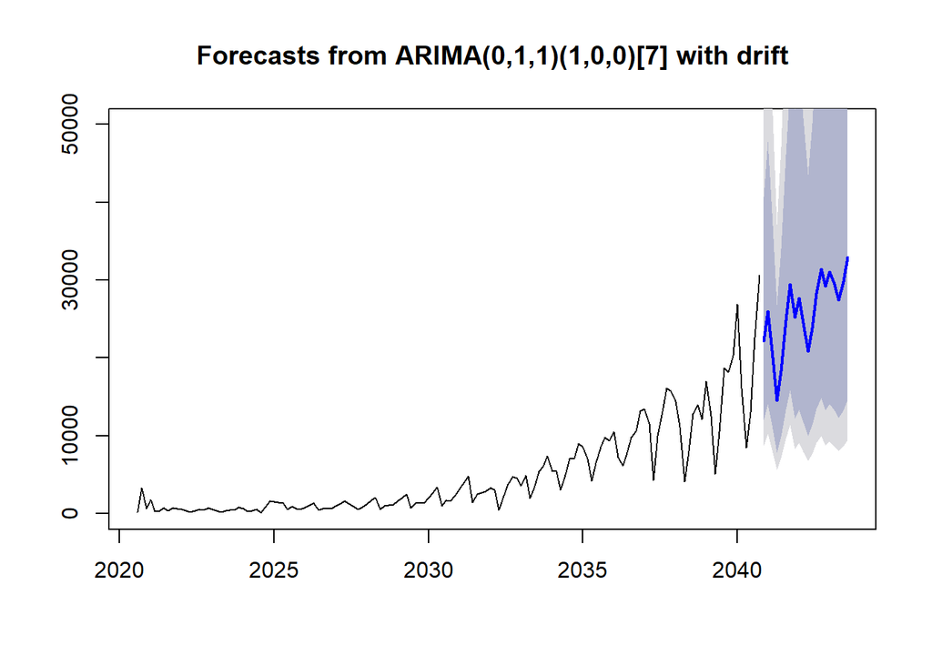

```r
pred = forecast(fit0, h = 20)
pred$x <- 10^(pred$x)
pred$mean <- 10^(pred$mean)
pred$lower <- 10^(pred$lower)
pred$upper <- 10^(pred$upper)
#plot(france_dataTS.withoutNA,type='l',xlim = c(2020, 2045), ylim = c(0, 50000), xlab = 'Day',ylab = 'New cases')
plot(pred, ylim = c(0, 50000))
```

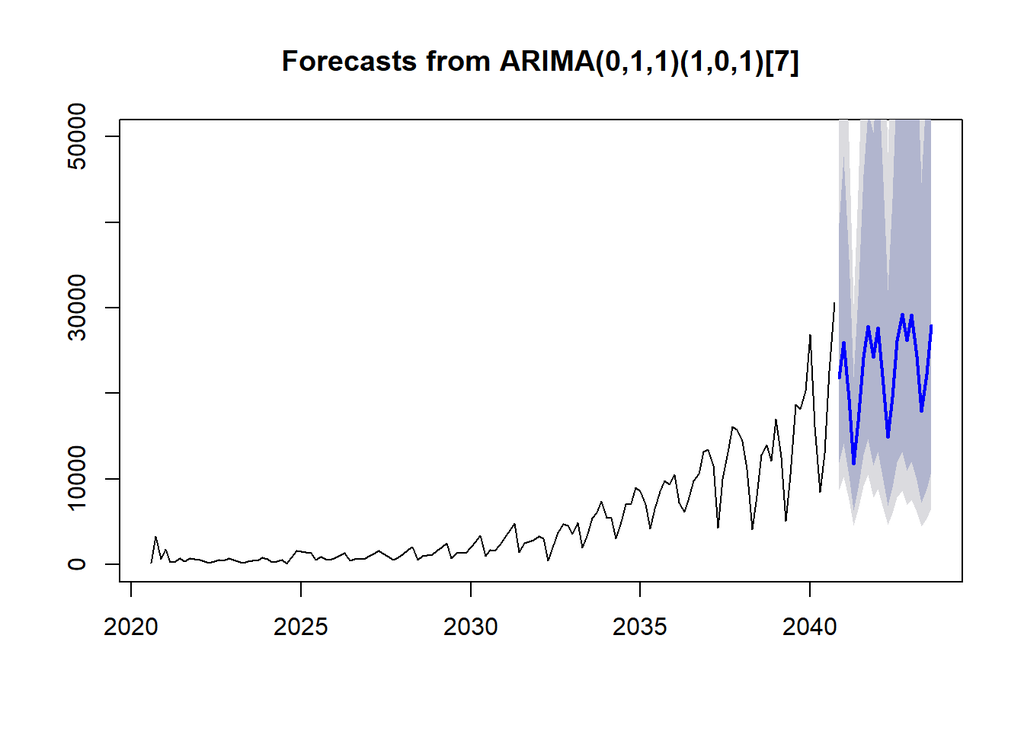

```r
pred = forecast(fit1, h = 20)
pred$x <- 10^(pred$x)
pred$mean <- 10^(pred$mean)
pred$lower <- 10^(pred$lower)
pred$upper <- 10^(pred$upper)
plot(pred, ylim = c(0, 50000))
```

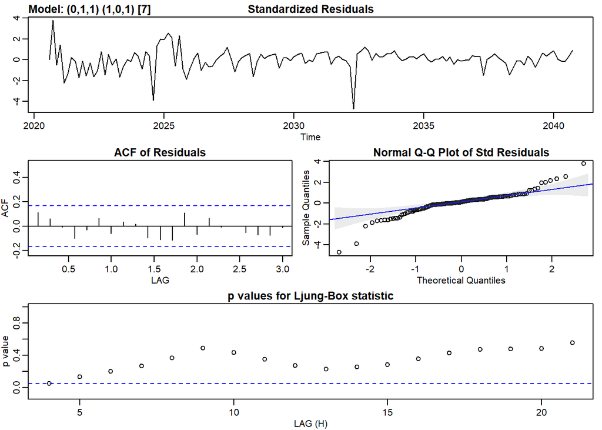

```
## $fit
##
## Call:
## stats::arima(x = xdata, order = c(p, d, q), seasonal = list(order = c(P, D,
##     Q), period = S), xreg = constant, transform.pars = trans, fixed = fixed,
##     optim.control = list(trace = trc, REPORT = 1, reltol = tol))
##
## Coefficients:
##           ma1    sar1     sma1  constant
##       -0.9058  0.7197  -0.2683    0.0101
## s.e.   0.0567  0.1303   0.1815    0.0042
##
## sigma^2 estimated as 0.04097:  log likelihood = 23.3,  aic = -36.6
##
## $degrees_of_freedom
## [1] 137
##
## $ttable
##          Estimate     SE  t.value p.value
## ma1       -0.9058 0.0567 -15.9622  0.0000
## sar1       0.7197 0.1303   5.5249  0.0000
## sma1      -0.2683 0.1815  -1.4781  0.1417
## constant   0.0101 0.0042   2.4375  0.0161
##
## $AIC
## [1] -0.2595545
##
## $AICc
## [1] -0.2574685
##
## $BIC
## [1] -0.1549885
```

```r
#sarima(france_dataTS.withoutNA.LOG, 1, 1, 0, 1, 0, 1, 7)
sarima(france_dataTS.withoutNA.LOG, 0, 1, 1, 1, 0, 1, 7)
```

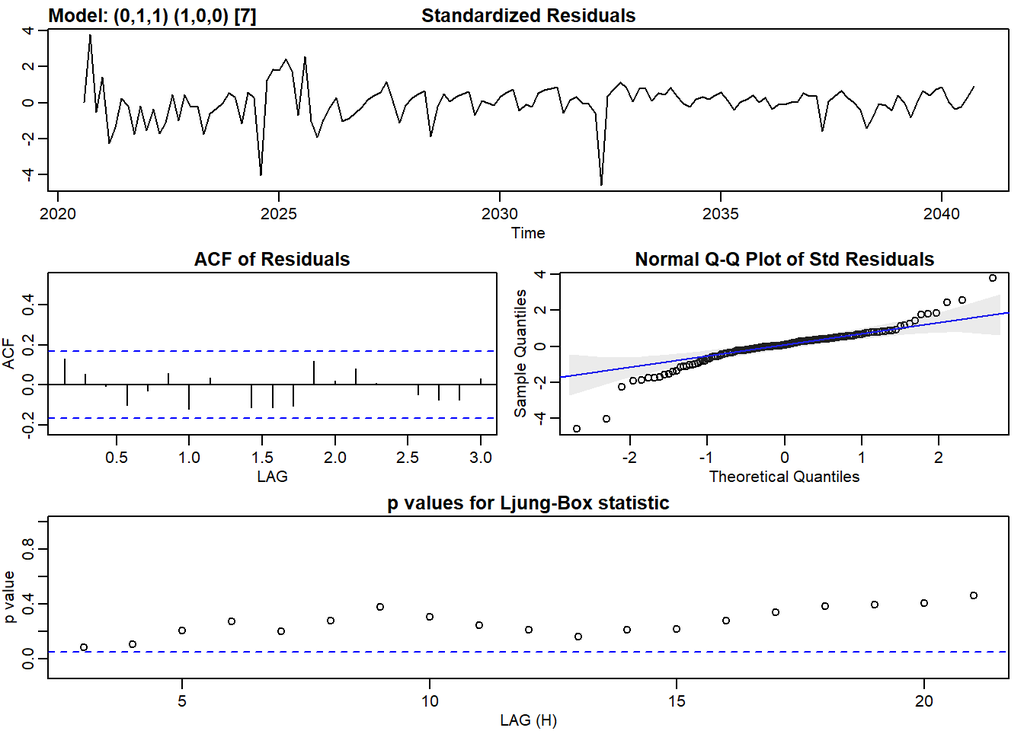

```
## $fit
##
## Call:
## stats::arima(x = xdata, order = c(p, d, q), seasonal = list(order = c(P, D,
##     Q), period = S), xreg = constant, transform.pars = trans, fixed = fixed,
##     optim.control = list(trace = trc, REPORT = 1, reltol = tol))
##
## Coefficients:
##           ma1    sar1  constant
##       -0.9158  0.5269    0.0107
## s.e.   0.0534  0.0819    0.0032
##
## sigma^2 estimated as 0.04159:  log likelihood = 22.4,  aic = -36.8
##
## $degrees_of_freedom
## [1] 138
##
## $ttable
##          Estimate     SE  t.value p.value
## ma1       -0.9158 0.0534 -17.1596  0.0000
## sar1       0.5269 0.0819   6.4357  0.0000
## constant   0.0107 0.0032   3.3352  0.0011
##
## $AIC
## [1] -0.2610052
##
## $AICc
## [1] -0.2597628
##
## $BIC
## [1] -0.1773524
```

```r
sarima(france_dataTS.withoutNA.LOG, 0, 1, 1, 1, 0, 0, 7)
```

```r
fit <- ets(france_dataTS.withoutNA, lambda = BoxCox.lambda(france_dataTS.withoutNA))
fit1 <- HoltWinters(france_dataTS.withoutNA)
fit
```

```
## ETS(A,A,A)
##
## Call:
##  ets(y = france_dataTS.withoutNA, lambda = BoxCox.lambda(france_dataTS.withoutNA))
##
##   Box-Cox transformation: lambda= 0.1296
##
##   Smoothing parameters:
##     alpha = 0.1155
##     beta  = 1e-04
##     gamma = 0.5326
##
##   Initial states:
##     l = 9.7628
##     b = 0.0708
##     s = -0.1339 -1.6878 -1.3971 2.0169 0.5452 2.5066
##            -1.8498
##
##   sigma:  1.1946
##
##      AIC     AICc      BIC
## 766.7738 769.1924 802.2438
```

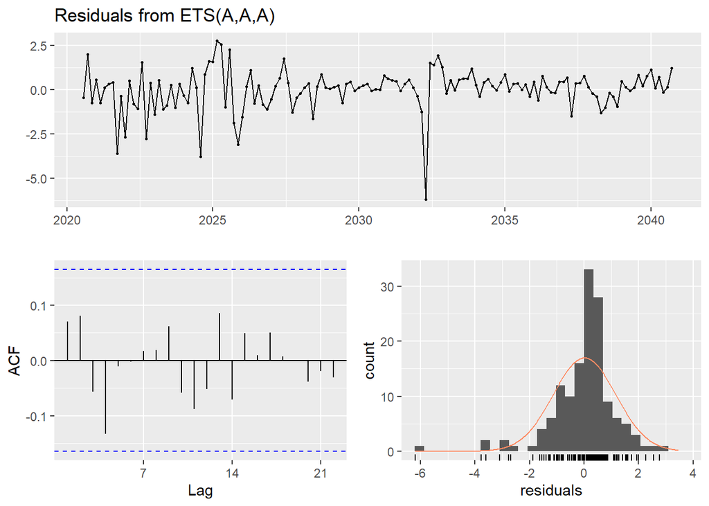

```
##
##  Ljung-Box test
##
## data:  Residuals from ETS(A,A,A)
## Q* = 9.5949, df = 3, p-value = 0.02234
##
## Model df: 11.   Total lags used: 14
```

```r
checkresiduals(fit)
```

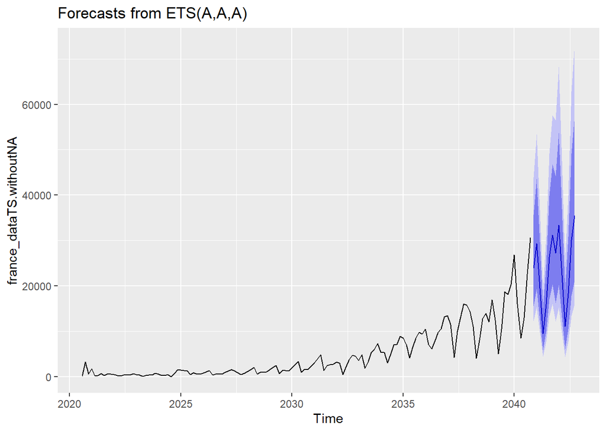

```r
autoplot(forecast(fit))
```

```r
fit1
```

```
## Holt-Winters exponential smoothing with trend and additive seasonal component.
##
## Call:
## HoltWinters(x = france_dataTS.withoutNA)
##
## Smoothing parameters:
##  alpha: 0.2856061
##  beta : 0.07739954
##  gamma: 1
##
## Coefficients:
##          [,1]
## a  19635.9494
## b    546.2262
## s1  5353.3698
## s2 10026.8519
## s3  -560.3866
## s4 -7993.0588
## s5 -3200.7785
## s6  5905.8325
## s7 10985.0506
```

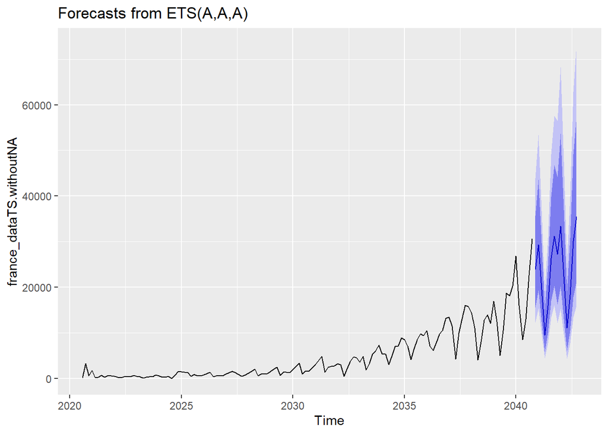

```r
autoplot(forecast(fit))
```